# PEC1. Análisis de datos Ómicos

Lára Kristjánsdóttir

16/11/2022

# 1 Introducción y objetivos

En este trabajo haremos una exploración del estudio “Arachidonic acid effect on prostate cancer cells”. Determinaremos su estructura y el diseño y luego exploramos los datos y hacemos análisis univariante y multivariante.

## 1.1 Información básica del estudio

Podemos ver el estudio “Omega-6 fatty acids, arachidonic acid (AA) activates PI3K signaling and induces gene expression in prostate cancer” mediante el GEOdataset o la GEOserie:

[GEOdataset GDS1736](https://www.ncbi.nlm.nih.gov/sites/GDSbrowser?acc=GDS1736)

[GEOserie GSE3737](https://www.ncbi.nlm.nih.gov/geo/query/acc.cgi?acc=GSE3737)

Fue publicado el 1 de enero de 2006 por Hughes-Fulford M, Li CF, Boonyaratanakornkit J, Sayyah S..

Consistió en analizar cultivos de células de cáncer de próstata en humanos utilizando ácido araquidónico, un ácido que ha demostrado ser importante en la proliferación de células cancerígenas.

## 1.2 Estructura y diseño

El experimento fue de tipo “Expression profiling by array” se realizó de la siguente manera:

“PC-3 prostate cancer cells were incubated with 5 µg/mL AA in RPMI containing 0.25 mg/mL albumin for 2hr. Control cells were treated with albumin alone and remained unactivated. Total RNA was isolated and relative gene expression was analyzed by Affymetrix gene arrays and then verified by qRTPCR. Microarrays for untreated and treated samples were done in quadruplicates.”

# 2 Métodos

## 2.1 Exploración de los datos

Empezamos descargando la información del experimento con `GEOquery` con la función `getGEO()`.

```
## Found 1 file(s)
```

```
## GSE3737_series_matrix.txt.gz
```

Veamos el objeto de “gse” y el “Expression set” que se crea automáticamente.

```
## [1] "list"
```

```
## [1] "GSE3737_series_matrix.txt.gz"
```

```
## [1] 1
```

```
## ExpressionSet (storageMode: lockedEnvironment)
## assayData: 22283 features, 8 samples
##   element names: exprs
## protocolData: none
## phenoData
##   sampleNames: GSM86079 GSM86080 ... GSM86086 (8 total)
##   varLabels: title geo_accession ... data_row_count (30 total)
##   varMetadata: labelDescription
## featureData
##   featureNames: 1007_s_at 1053_at ... AFFX-TrpnX-M_at (22283 total)
##   fvarLabels: ID Gene title ... GO:Component ID (21 total)
##   fvarMetadata: Column Description labelDescription
## experimentData: use 'experimentData(object)'
##   pubMedIds: 16452198
## Annotation: GPL96
```

Veamos el objeto “gds” y creamos el Expression Set.

```
## [1] "GDS"
## attr(,"package")
## [1] "GEOquery"
```

```
## [1] "gpl"       "dataTable" "header"
```

```
## Using locally cached version of GPL96 found here:
## C:\Users\saeti\AppData\Local\Temp\RtmpYt0HUk/GPL96.annot.gz
```

Ahora exploramos el Expression set. Empezamos con la información de los genes.

```
##  [1] "ID"                    "Gene title"            "Gene symbol"
##  [4] "Gene ID"               "UniGene title"         "UniGene symbol"
##  [7] "UniGene ID"            "Nucleotide Title"      "GI"
## [10] "GenBank Accession"     "Platform_CLONEID"      "Platform_ORF"
## [13] "Platform_SPOTID"       "Chromosome location"   "Chromosome annotation"
## [16] "GO:Function"           "GO:Process"            "GO:Component"
## [19] "GO:Function ID"        "GO:Process ID"         "GO:Component ID"
```

Luego vemos los datos de la expresión genética y la información fenotípica.

```
##           GSM86079 GSM86080 GSM86081 GSM86082 GSM86083 GSM86084 GSM86085
## 1007_s_at    738.9    620.1    706.6    985.2    664.3    557.2    991.6
## 1053_at       96.1    312.8    129.9    341.1    109.1    143.4    420.5
## 117_at       100.8     83.1     83.5    245.5    102.3     66.2    161.5
## 121_at       823.4    646.2    805.9   1122.7    635.1    598.1    991.9
## 1255_g_at     38.3     23.2     13.0     51.3     29.9     23.7     47.9
## 1294_at      239.7    100.6    180.3    198.9    249.8    150.6    106.0
##           GSM86086
## 1007_s_at    873.5
## 1053_at      439.2
## 117_at       185.2
## 121_at       809.9
## 1255_g_at     56.9
## 1294_at       90.7
```

De la información fenotípica, podemos por ejemplo ver a qué grupo pertenece cada observación.

```
##            sample            agent
## GSM86079 GSM86079          control
## GSM86080 GSM86080          control
## GSM86081 GSM86081          control
## GSM86082 GSM86082          control
## GSM86083 GSM86083 arachidonic acid
## GSM86084 GSM86084 arachidonic acid
## GSM86085 GSM86085 arachidonic acid
## GSM86086 GSM86086 arachidonic acid
##                                                                description
## GSM86079               Value for GSM86079: 1 PC3 0hr; src: PC-3, untreated
## GSM86080              Value for GSM86080: 1 PC3 0hra; src: PC-3, untreated
## GSM86081               Value for GSM86081: 2 PC3 0hr; src: PC-3, untreated
## GSM86082        Value for GSM86082: B final PC3 ctrl; src: PC-3, untreated
## GSM86083          Value for GSM86083: 3 PC3 2hr; src: PC-3, AA treated 2hr
## GSM86084          Value for GSM86084: 4 PC3 2hr; src: PC-3, AA treated 2hr
## GSM86085 Value for GSM86085: C final PC3 AA 2hr; src: PC-3, AA treated 2hr
## GSM86086 Value for GSM86086: D final PC3 AA 2hr; src: PC-3, AA treated 2hr
```

Exploramos la matriz de expresión para familiarizarnos con el dataset, viendo las dimensiones y los nombres de las columnas.

```
## [1] 22283     8
```

```
## [1] "GSM86079" "GSM86080" "GSM86081" "GSM86082" "GSM86083" "GSM86084" "GSM86085"
## [8] "GSM86086"
```

Ahora vemos el resumen estadístico.

```
##         GSM86079 GSM86080 GSM86081 GSM86082 GSM86083 GSM86084 GSM86085 GSM86086
## Min.           0        0        0        0        0        0        0        0
## 1st Qu.       28       24       28       46       25       25       41       37
## Median        98       89       97      174       91       89      164      151
## Mean         368      356      353      772      359      382      700      703
## 3rd Qu.      289      283      291      552      289      285      568      554
## Max.       21604    13463    16852    39899    16379    29873    26968    25612
```

## 2.2 Análisis estadístico univariante

Hacemos un histograma para cada columna y vemos si existe una asimetría entre los datos.

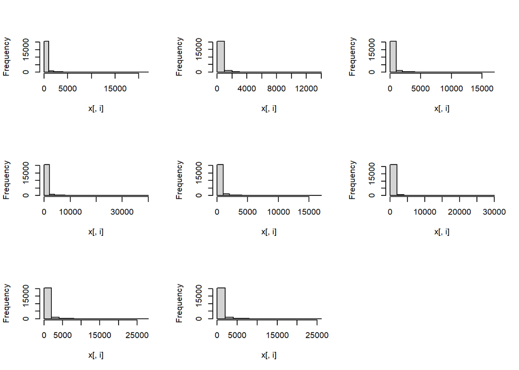

Para ver mejor si hay asimetría hacemos un boxplot con todas las muestras y pintamos los grupos de distintos colores.

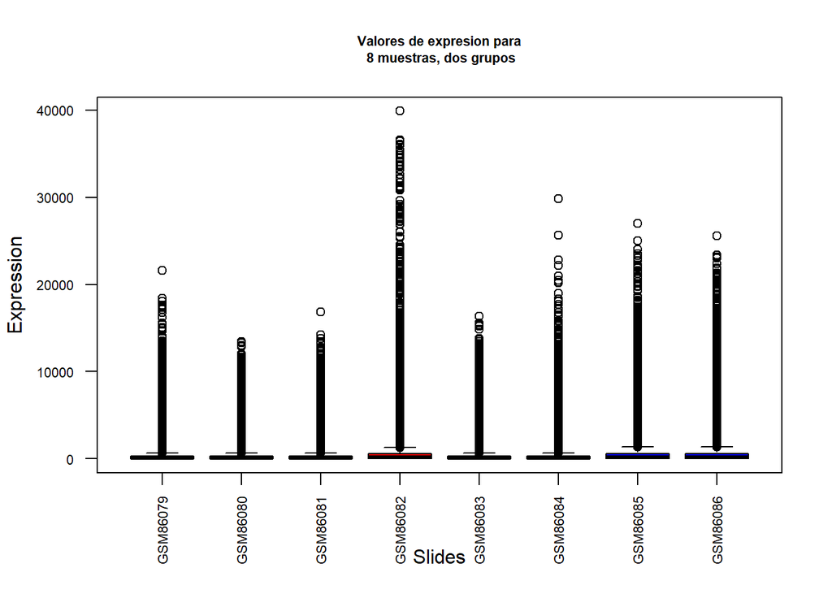

De la gráfica se puede sacar poca información, así que hacemos el boxplot de nuevo con el logaritmo de los valores de expresión.

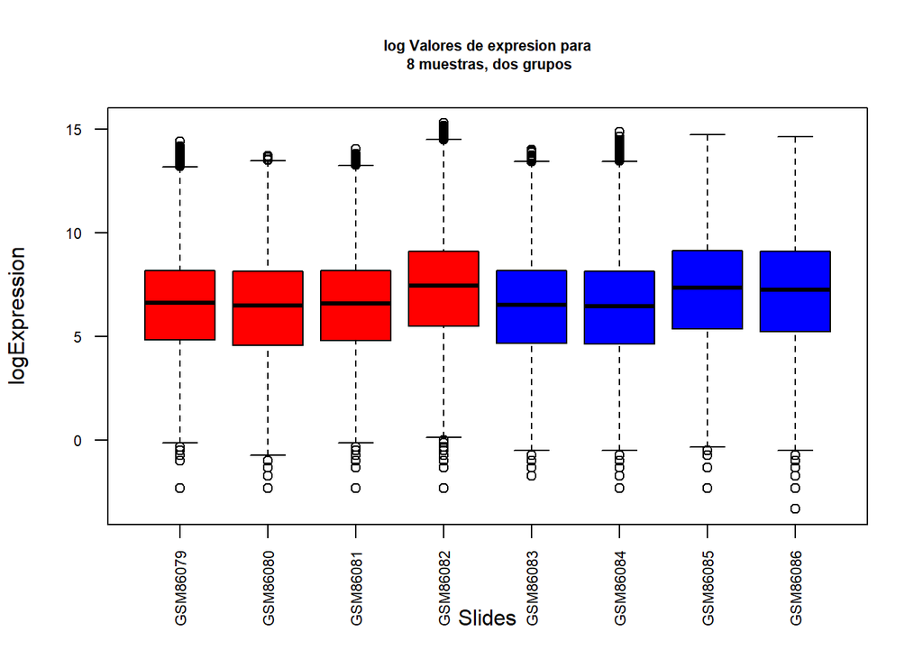

## 2.3 Visualización multivariante de los datos

Para ver si exsisten valores atípicos, hacemos una gráfica donde calculamos “sample-wise” los componentes principales y luego dibujamos los primeros componentes. Empezamos calculando los componentes principales y las cargas.

Luego dibujamos las dos primeras componentes.

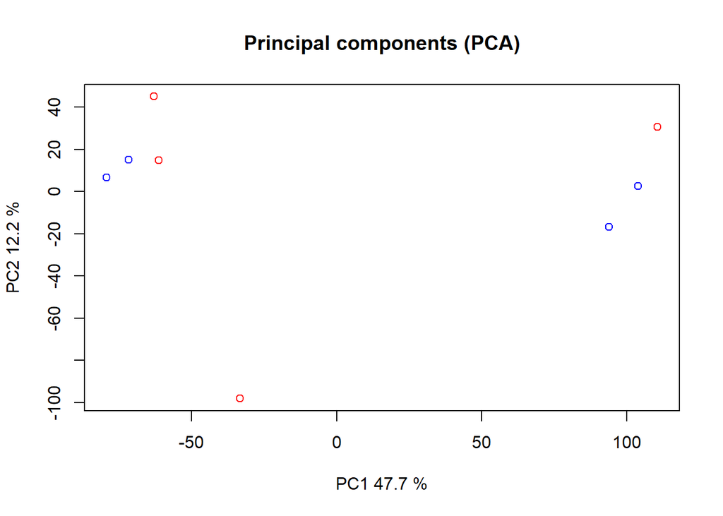

Hacemos ahora clustering jerárquico para ver la agrupación esperada o también para ver si hay algún tipo de agrupación a descubrir.

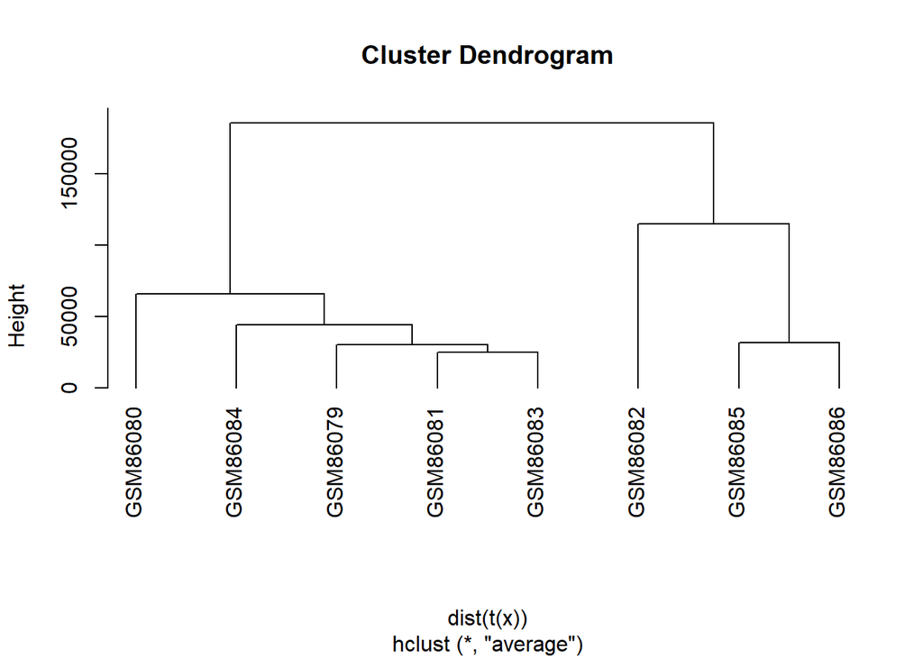

# 3 Resultados

En la exploración univariante se ve cierta simetría entre los dos grupos. De la exploración multivariante vemos que ni en el PCA ni en el clustering se puede ver una agrupación entre los dos grupos pero que hay otra agrupación que es consitente con el boxplot de la exploración univariante.

# 4 Apéndices

```r
knitr::opts_chunk$set(echo = TRUE)
# Libraries

library(BiocManager)
library(GEOquery)
# Loading data with GEOquery

gse <- getGEO("GSE3737", GSEMatrix=TRUE, AnnotGPL=TRUE) # a list, each of which elements is an expressionSet
gds <- getGEO("GDS1736") # A class comprised of a metadata header and a GEODataTable
# Información la lista gse3737

class(gse)
names(gse)
length(gse)
gse[[1]]
esetFromGEO <- gse[[1]]

# Information on the gds class and turn gds class into expression set

class(gds)
slotNames(gds)
eset <- GDS2eSet(gds,do.log2=FALSE)

# Information about the genes

colnames(fData(esetFromGEO))

# Gene expression data

head(exprs(eset))
# phenotipic information

pData(eset)
# Exploring data

x <- exprs(eset)
dim(x)      # Dimensions
colnames(x)    # Vector of strings to name the columns
# summarizing  data

round(apply(x,2, summary))

# Visualizing dataset

# Histogram
opt <- par(mfrow=c(3,3))
for (i in 1:ncol(x))
  hist(x[,i], main = names(x)[i])
par(opt)

# Boxplot expression value

groupColors <- c(rep("red", 4), rep("blue", 4))
boxplot(x, col=groupColors, main="Valores de expresion para\n 8 muestras, dos grupos",
    xlab="Slides",
    ylab="Expression", las=2, cex.axis=0.7, cex.main=0.7)

# Boxplot Log expression value

logX <- log2(x)
groupColors <- c(rep("red", 4), rep("blue", 4))
boxplot(logX, col=groupColors, main="log Valores de expresion para\n 8 muestras, dos grupos",
    xlab="Slides",
    ylab="logExpression", las=2, cex.axis=0.7, cex.main=0.7)
# PCA

pcX<-prcomp(t(logX), scale=FALSE) # Ya se han escalado los datos
loads<- round(pcX$sdev^2/sum(pcX$sdev^2)*100,1)
# Plot PCA
xlab<-c(paste("PC1",loads[1],"%"))
ylab<-c(paste("PC2",loads[2],"%"))
names2plot<-paste0(substr(names(x),1,3), 1:4)
plot(pcX$x[,1:2],xlab=xlab,ylab=ylab, col=groupColors,
     main ="Principal components (PCA)")

names(x) <- names2plot
clust.euclid.average <- hclust(dist(t(x)),method="average")
plot(clust.euclid.average, hang=-1)
```